# Climate policies exclusively centered in the Global North harm the economy of the Global South

Policy lessons of a two-region input-output ecological macroeconomic model

Oriol Vallès Codina

2026-01-14

# Introduction

## Outline

- ECO-MRIO-SFC modeling as a tool to understand the very **complex impact of (carbon) taxes and tariffs on global value chains** from a socio-economic perspective: ecological, macroeconomic and distributional implications for class, gender, race / region
- Trade wars and global value chain fragmentation/regionalization
- **Challenge** how to overcome ecological unequal exchange?
- Current model shows ecological and economic impacts are best in cooperative models
- Implications: competition vs cooperation in trade (Blecker 2025)

## Motivation: Exchange is Unequal

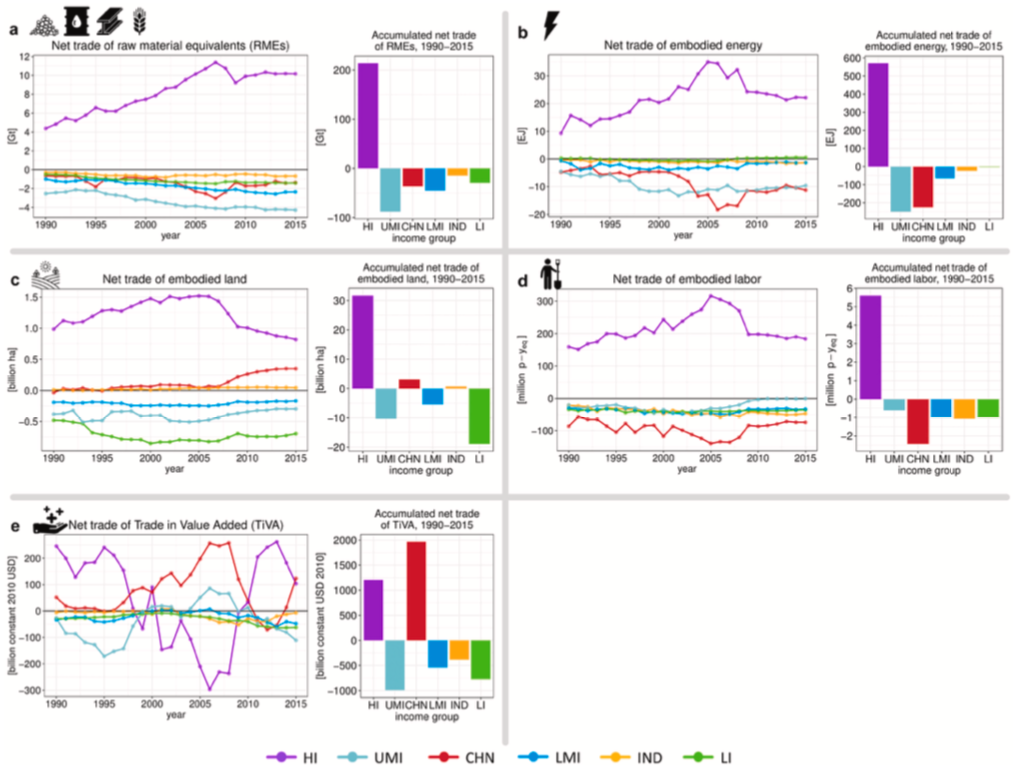

## Starting Point: the JUST2CE project

- **JUST2CE** = A Just Transition to the Circular Economy
- EU-funded project proposing an alternative way of looking at CE
- Most projects have focused on *how* to produce circularity. JUST2CE focuses on *what* (democracy, participation, gender, global justice)
- Two milestones / WP5 deliverables:
  - **Systematic review** of macro models assessing CE transition (**Fevereiro et al 2025**)
  - **Formal model(s)** to simulate & compare CE policies and transition scenarios (**Vallès Codina et al., 2026?**)

## Systematic Literature Review

[figure not shown]

## Systematic Literature Review (Simplified)

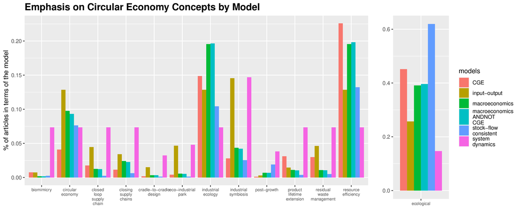

## Citation Network of Ecological Macroeconomics

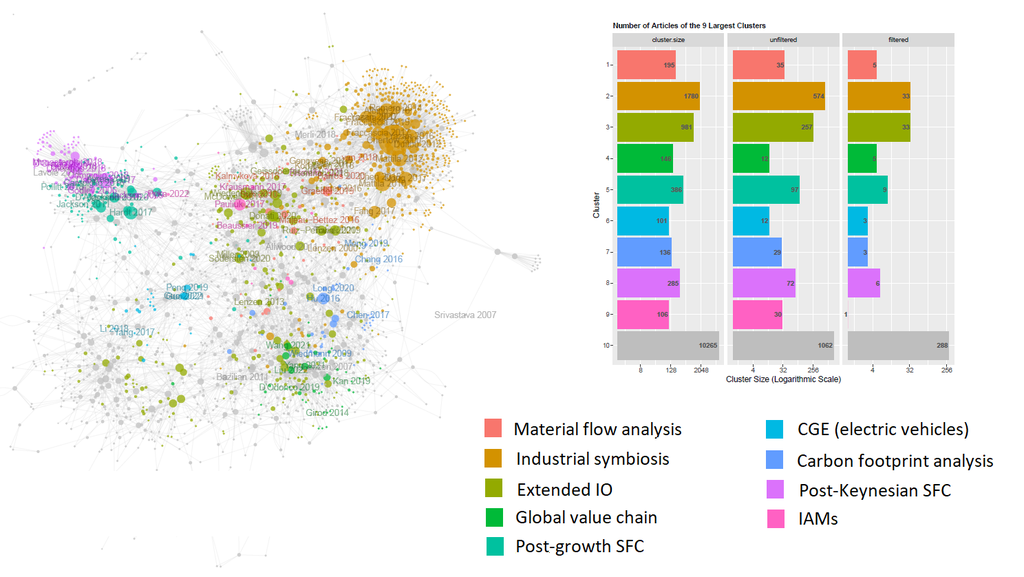

## Main Gaps Identified

- **Modelling of Rebound Effects** — limited treatment of demand/impact changes via prices, jobs, income
- **Transitional Dynamics** — IO analysis typically static
- **Limited Socio-Economic Coverage** — often only employment considered
- **Technology Innovation & Diffusion; Demand Assumptions** — low-labor-cost tech may be preferred
- **North–South / Core–Periphery Ecological Unequal Exchange** (Dorninger 2021, Hickel)

# ECO–MRIO–SFC Modeling

## The Model: Basic Features

Main tools in (theory-to-data) **macroeconomics**:

1. **DSGE (and growth) models** — *Pros*: mainstream, simple story. *Cons*: “small”, unique optimal equilibrium
2. **CGE models (and IAMs)** — *Pros*: many variables, cross-industry links. *Cons*: unique optimal equilibrium, no finance

Cross-breeding two alternatives *(Hardt & O’Neill 2017)*:

- **Leontief IO Models** — *Pros*: many variables, cross-industry links. *Cons*: static, no finance
- **SFC Models** — *Pros*: dynamics, finance. *Cons*: homogeneous output

## Theoretical Antedecents

- Increasing use of IO–SFC models; yet none focuses on CE:
- *Berg, Hartley & Richters (2015)*. A stock-flow consistent input-output model with applications to energy price shocks, interest rates, and heat emissions.
- **Other contributions** *Naqvi (2015)*; *Naqvi and Stockhammer (2018)*; Valdecantos & Valentini (2017); Nieto et al (2019); Jackson & Jackson (2021); Cordier et al. (2015); Jackson et al. (2014)
- MEDEAS, Eurogreen, REAL, ToBe… increasingly very sophisticated one-region models

## Final Demand and Gross Output: Constant Sector Shares

Let us consider a $3\times 3$ production. The **final demand** vector is:

$$\mathbf{d}
= \begin{bmatrix} \beta_1 \\ \beta_2 \\ \beta_3 \end{bmatrix} c
+ \begin{bmatrix} \iota_1 \\ \iota_2 \\ \iota_3 \end{bmatrix} i_d
+ \begin{bmatrix} \sigma_1 \\ \sigma_2 \\ \sigma_3 \end{bmatrix} gov
+ \begin{bmatrix} \eta_1 \\ \eta_2 \\ \eta_3 \end{bmatrix} exp$$

The **gross output** vector is:

$$\mathbf{x} = \mathbf{A} \mathbf{x} + \mathbf{d} = (\mathbf{I}-\mathbf{A})^{-1}\mathbf{d}, \quad
\mathbf{A} = \begin{bmatrix}
a_{11} & a_{12} & a_{13} \\
a_{21} & a_{22} & a_{23} \\
a_{31} & a_{32} & a_{33}
\end{bmatrix}$$

## Classical Approach to Prices

For $i = 1, ..., KN$ commodities where there are $K$ regions and $N$ products per region:

$$p = w l + p A (1 + \mu_i) (1 + \kappa_i \delta_i)$$

Isolating prices,
$$p = w l [I - (1 + \mu) (1 + \kappa \delta) A]^{-1} = w l B = w v$$

where $v \equiv l B$ and the augmented Leontief matrix is

$$B \equiv [I - (1 + \mu) (1 + \kappa \delta) A]^{-1}$$

under uniform profitability rate $\mu$ and hence different markups.

## Carbon Taxation

Carbon taxes are internalized as a production cost for all commodities:

$$p' = p (1 + \tau)$$

where $p = w l B$ is the price before tax, $p'$ is the price with tax, and $\tau$ is the product of emission intensity times the carbon price. In scalar notation, we write $p_i = w \sum_j l_j b_{ji}$ so that adding the carbon price yields:

$$p'_i = w (1 + \tau_i) \sum_j l_j b_{ji}$$

## (Carbon) Tariffs 1

We need to exploit the $KN \times KN$ dimensionality of global matrix of input-output coefficients $A$ and thus the augmented Leontief matrix $B$. For $K = N = 2$, 2 products and 2 regions, labeled 1 to 4:

$$p = w (l_1, l_2, l_3, l_4) \begin{pmatrix} b_{11} & b_{12} & b_{13} & b_{14} \\ b_{21} & b_{22} & b_{23} & b_{24} \\ b_{31} & b_{32} & b_{33} & b_{34} \\ b_{41} & b_{42} & b_{43} & b_{44} \end{pmatrix}$$

## (Carbon) Tariffs 2

In the carbon taxation case, we defined $1 + \tau$ as a $KN$-vector, but it can also be thought of a diagonal matrix with zeros in the off-diagonal. For the tariffs case, operate precisely on the off-diagonal matrices that refer to interregional trade. If region 1 imposes a tariff $(\tau_3, \tau_4)$ on products 1 and 2 of region 2, we multiply coefficients $b_{ij}$ by $(1 + \tau_i)$ for $i = 3,4$ and $j = 1,2$:

$$p' = w (l_1, l_2, l_3, l_4) \begin{pmatrix} b_{11} & b_{12} & b_{13} & b_{14} \\ b_{21} & b_{22} & b_{23} & b_{24} \\ b_{31}(1 + \tau_3) & b_{32}(1 + \tau_3) & b_{33} & b_{34} \\ b_{41}(1 + \tau_4) & b_{42}(1 + \tau_4) & b_{43} & b_{44} \end{pmatrix}$$

## Ecological Unequal Exchange: EU (red) vs RoW (green)

**Table of Industries**

| # | Industry |
| --- | --- |
| 1 | Agriculture |
| 2 | Animal Farming |
| 3 | Forestry, logging and related service activities (02) |
| 4 | Fishing, operating of fish hatcheries and fish farms; service activities incidental to fishing (05) |
| 5 | Extraction of Fossil-Fuels |
| 6 | Mining & Quarrying of raw materials |
| 7 | Processing of meat |
| 8 | Processing of other food & beverage |
| 9 | Manufacture of tobacco products (16) |
| 10 | Manufacture of textiles |
| 11 | Manufacture of wood and of products of wood and cork, except furniture; manufacture of articles of straw and plaiting materials (20) |
| 12 | Re-processing of secondary wood material into new wood material |
| 13 | Pulp |
| 14 | Re-processing of secondary paper into new pulp |
| 15 | Paper |
| 16 | Processing of Fossil Fuels |
| 17 | Plastics, basic |
| 18 | Re-processing of secondary plastic into new plastic |
| 19 | Manufacture of Chemicals |
| 20 | Manufacture of rubber and plastic products (25) |
| 21 | Manufacture of glass and glass products |
| 22 | Re-processing of secondary glass into new glass |
| 23 | Manufacture of other non-metallic mineral products |
| 24 | Manufacture of cement, lime and plaster |
| 25 | Re-processing of ash into clinker |
| 26 | Manufacture of Metals |
| 27 | Re-processing of Metals |
| 28 | Manufacture of durable goods |
| 29 | Manufacture of furniture; manufacturing n.e.c. (36) |
| 30 | Recycling |
| 31 | Production of electricity by fossil fuels |
| 32 | Production of electricity by renewable energy |
| 33 | Transmission & Distribution |
| 34 | Manufacture of gas; distribution of gaseous fuels through mains |
| 35 | Water |
| 36 | Construction (45) |
| 37 | Re-processing of secondary construction material into aggregates |
| 38 | Sale, maintenance, repair of motor vehicles, motor vehicle parts, motorcycles, motorcycle parts and accessories |
| 39 | Retail sale of automotive fuel |
| 40 | Retail & Wholesale trade |
| 41 | Leisure Services |
| 42 | Transport |
| 43 | KIBS |
| 44 | Real estate activities (70) |
| 45 | Renting of machinery and equipment without operator and of personal and household goods (71) |
| 46 | Research and development (73) |
| 47 | Public administration and defence; compulsory social security (75) |
| 48 | Education (80) |
| 49 | Health and social work (85) |
| 50 | Incineration of Waste |
| 51 | Biogas & Composting |
| 52 | Waste water |
| 53 | Landfill of Waste |
| 54 | Other Services |

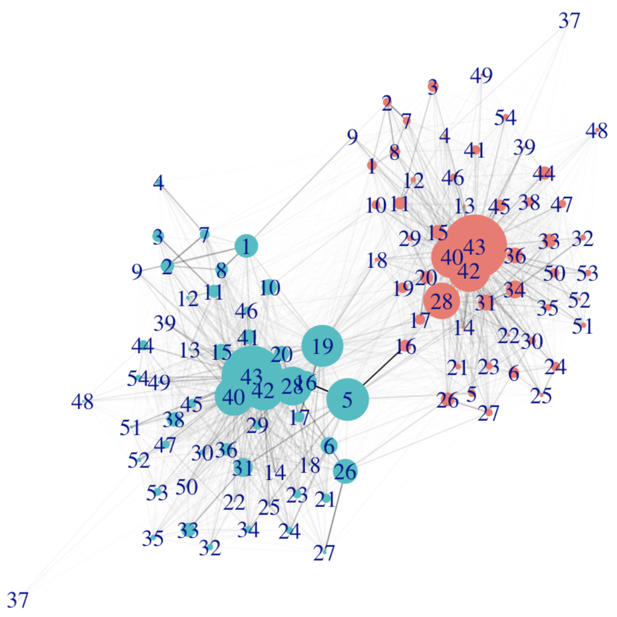

## Input-Output Network

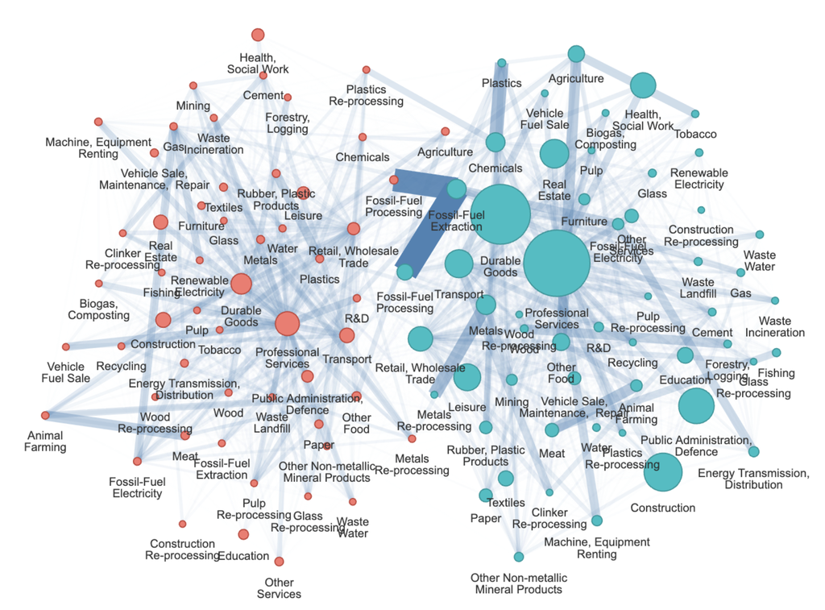

## Top Nodes

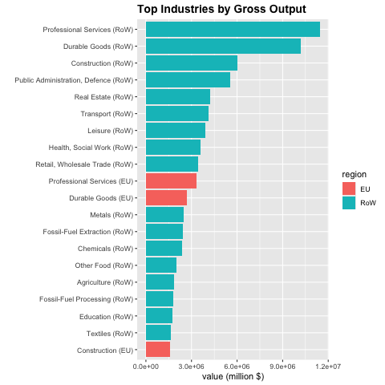

## Top Links

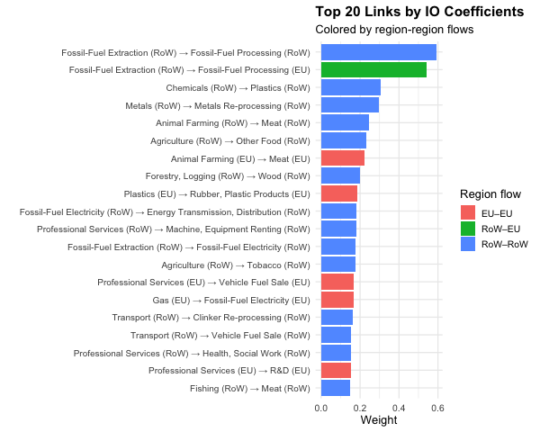

## Carbon Intensity

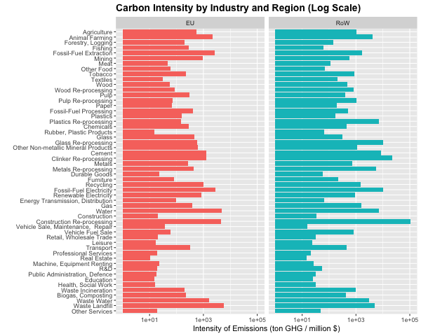

## Matter Intensity

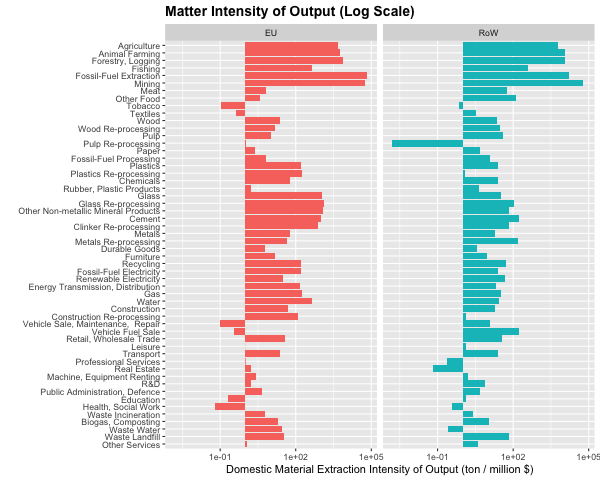

## Modeling Circular Economy Interventions 1: Product Lifetime Extension

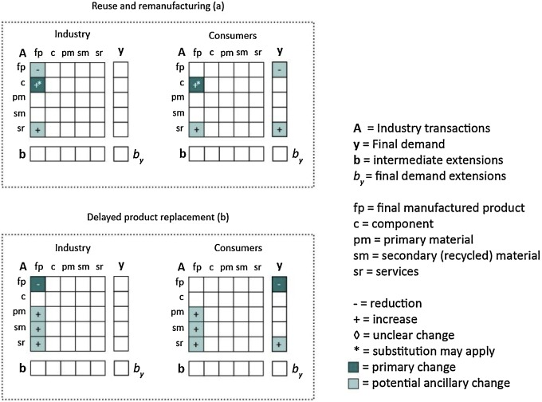

## Modeling Circular Economy Interventions 2: Resource Efficiency

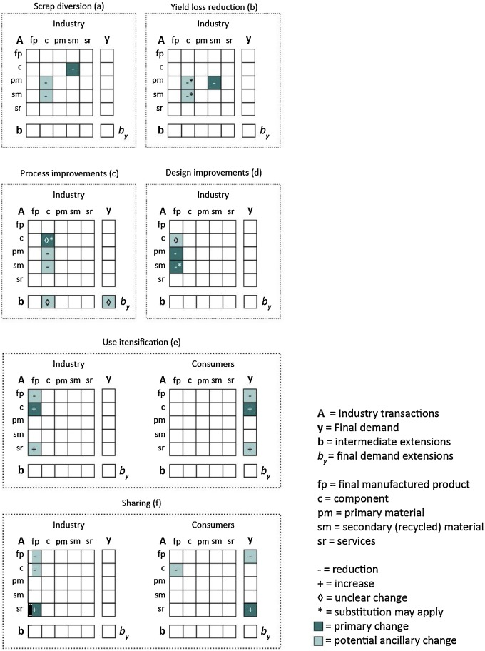

# Results

## Balance Sheet

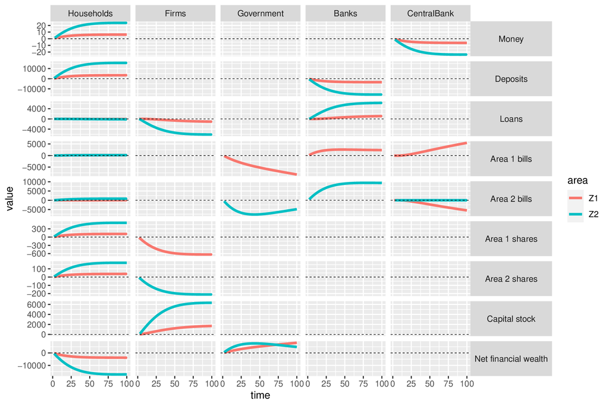

## Transaction-Flow Matrix

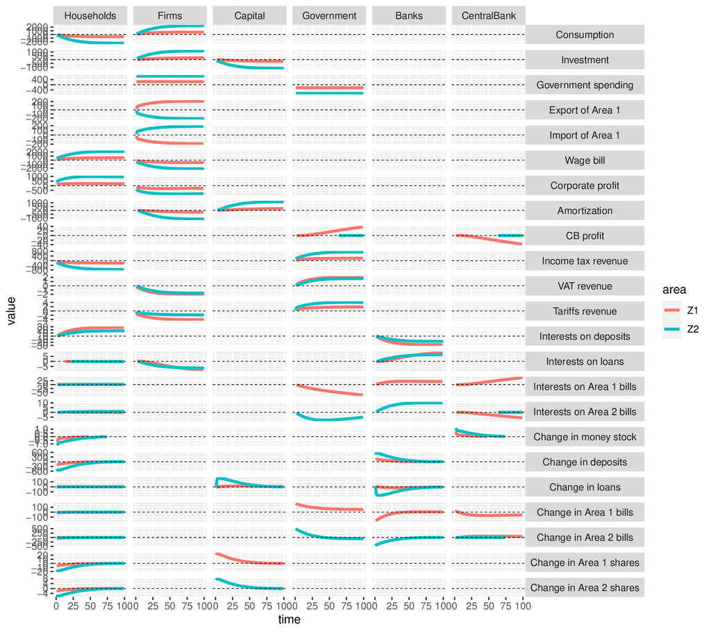

## TFM Formulas

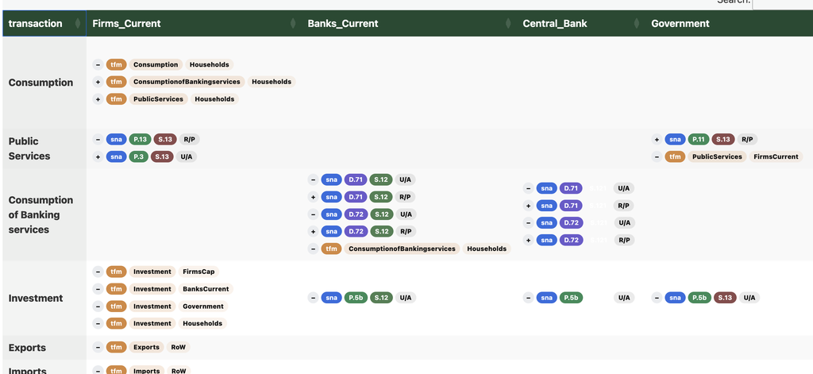

## Multi-Region Input–Output

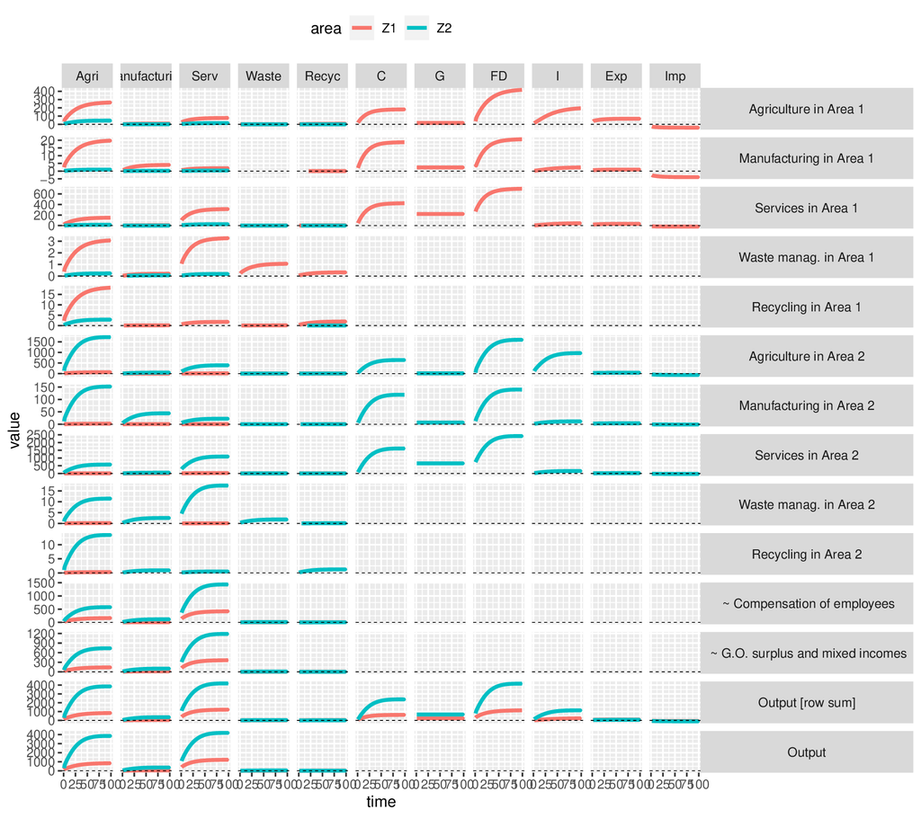

# Calibration

## Instruments Evolution

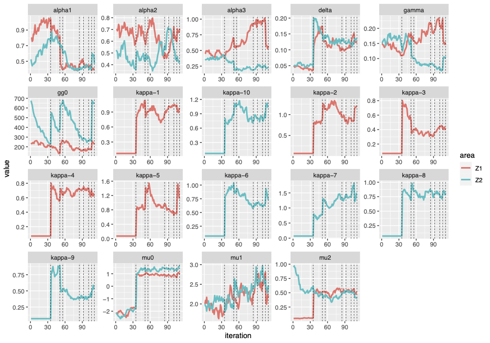

## Ratio Evolution

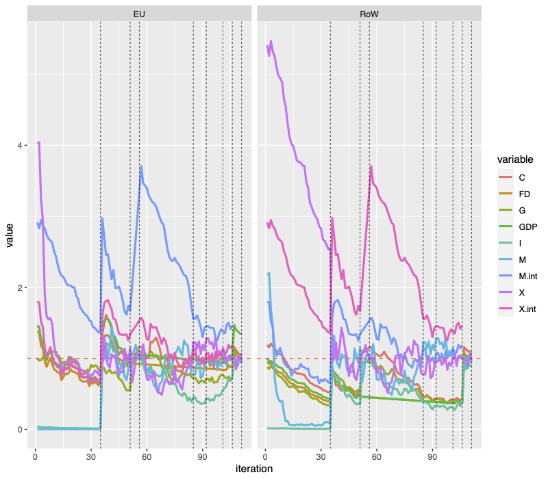

## Calibration Result

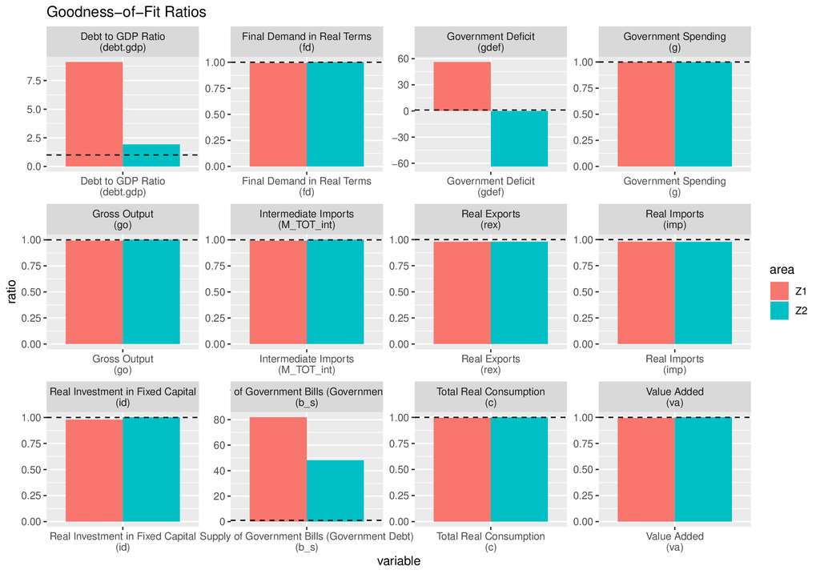

# Scenario Analysis

## Shocks

| **Shock** |
| --- |
| Reduction in Consumption Level |
| Change in Consumption Composition towards Services |
| Product Life Time Extension |
| Higher Recycling Rate |
| Higher Propensity to Consume Green |
| Lower Extraction (or Conversion) Rate of Matter |
| Lower Discarding Rate of Socio-Economic Stock |
| Higher Renewable Energy Share |
| Higher Govt Spending towards Efficiency |
| More Selective Govt Spending towards Recycling Efficiency |
| More Progressive Taxation |

## Scenario: Reduction in Consumption Level

**Top half**

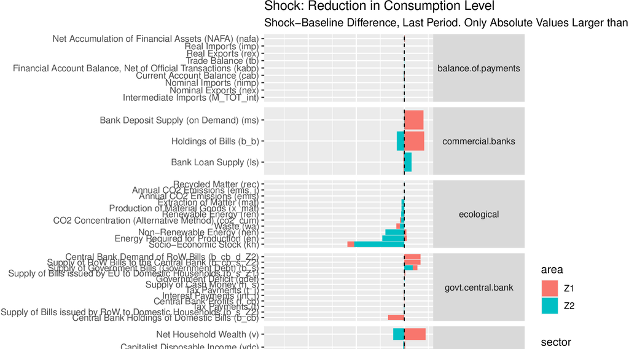

**Bottom half**

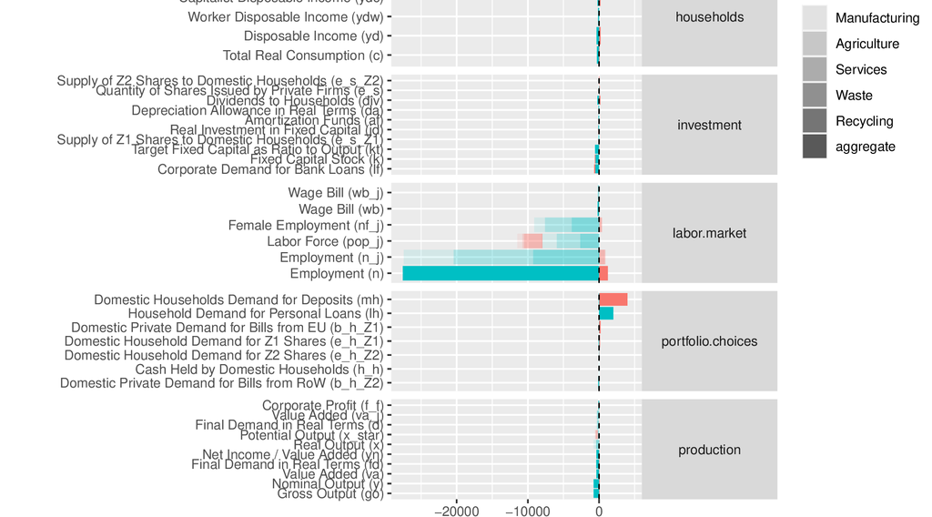

## Scenario: Product Lifetime Extension

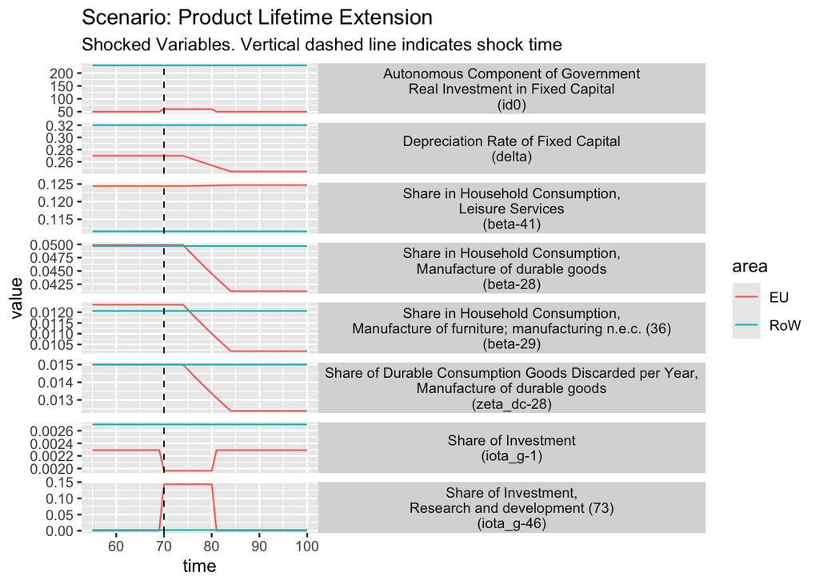

## Impact: Product Lifetime Extension

**External Indicators**

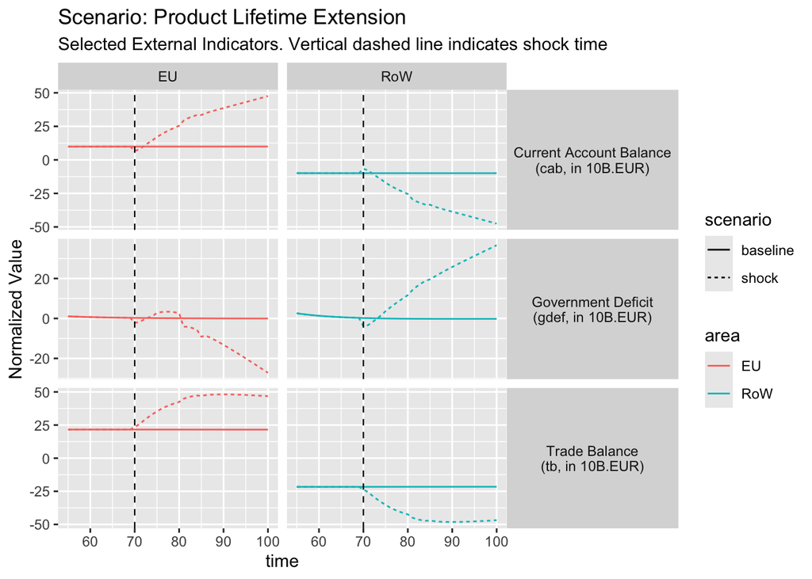

**Social Indicators**

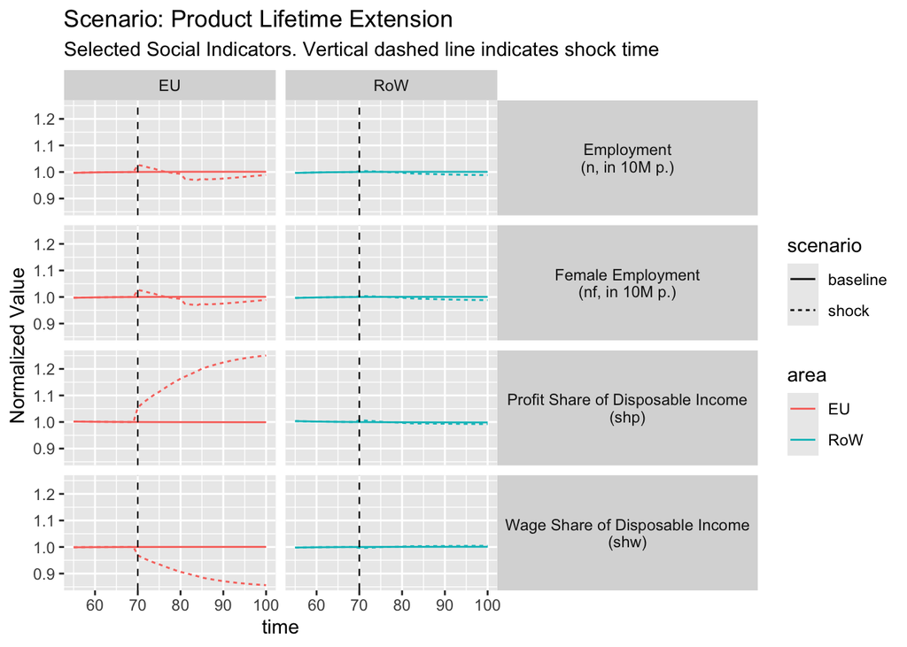

**Ecological Indicators**

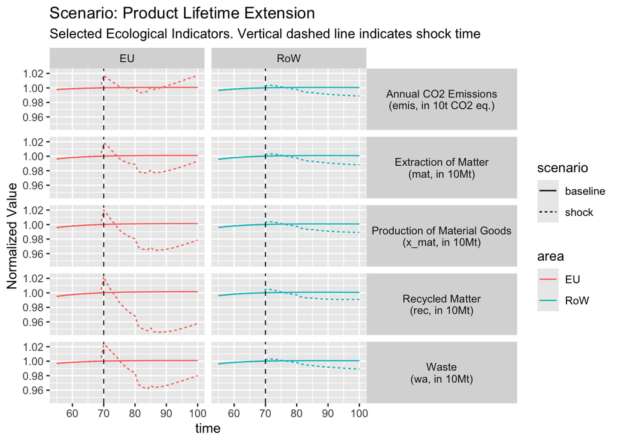

## Government-led CE Transition

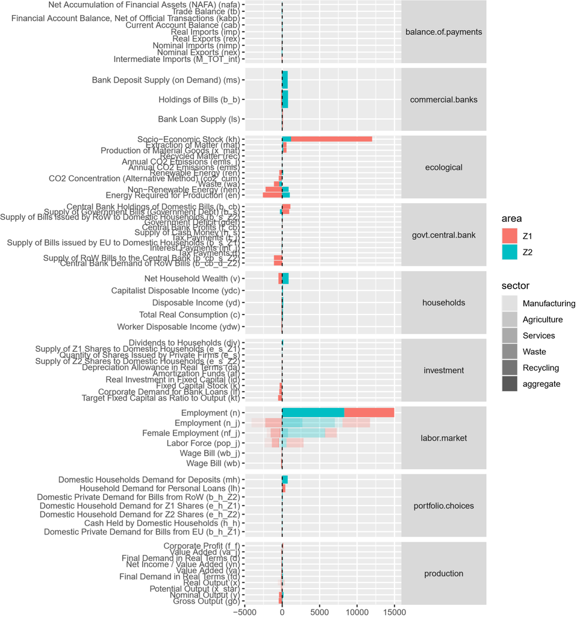

## Scenario Summary: Change by Shock, Difference

**Top half**

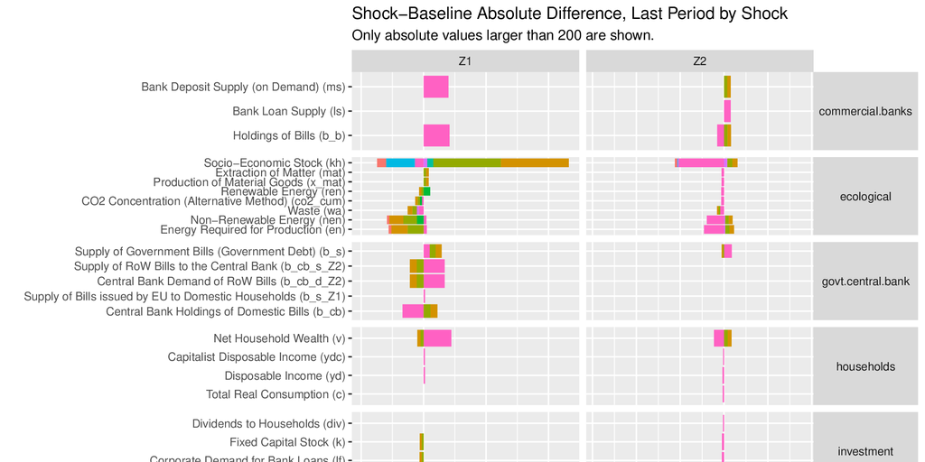

**Bottom half**

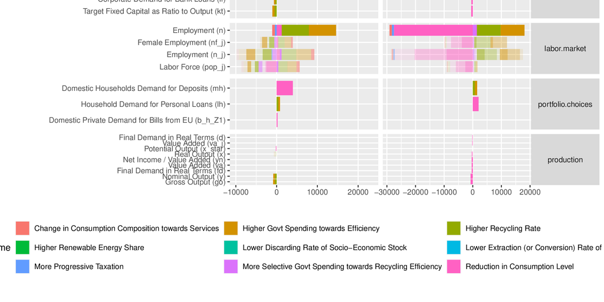

## Scenario Summary: Change by Shock, Percent

**Top half**

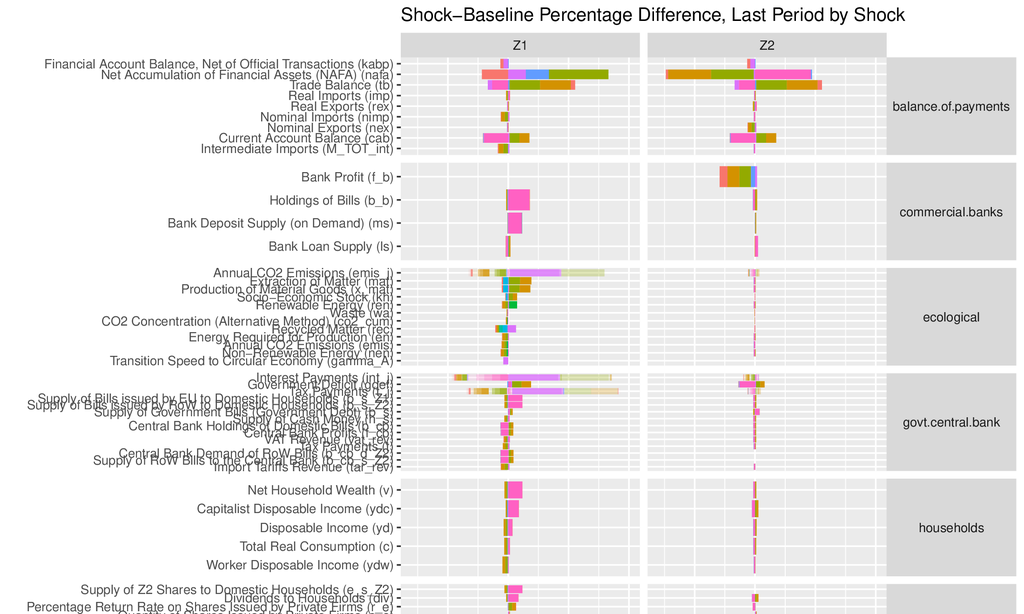

**Bottom half**

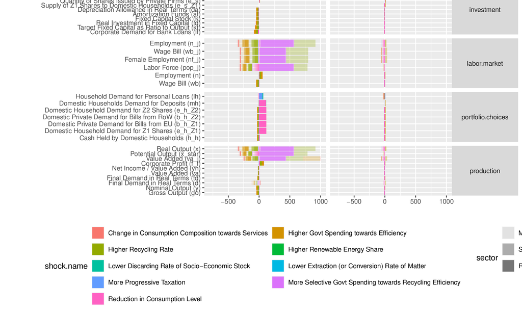

## Future Scenarios

> Changes in Household Final Consumption Shares
- **Dietary transition:** reduced meat consumption *(Sector 7 → 8)*
- **Energy use transition:** *(Sector 31 → 32)*

## Future Work

- Make explicit the military sector (military Keynesianism) and migration as a dynamic feedback
- **Green value chain upgrading** from the NZIPL green tech dataset
- NZIPL Net-Zero Value Chain Explorer

# Thank you!

oriolvallescodina@gmail.com

ovalles1@jh.edu